# Documento de manejo de variables OCS

# Introducción

El siguiente documento tiene como fin ayudar en el manejo y operacionalización de variables de la base de datos del Observatorio de Conflictos. Para estos fines se utiliza una serie de paquetes mínimos que pueden ayudar en esta tarea que permita la realización de análisis visuales. El documento se divide en dos partes: (1) Filtro y manejo de variables; (2) Visualización en ggplot2.

## Preparación de datos

En esta sección podemos observar algunas librerías mínimas que pueden ayudar en la recodificación de variables y creación de nuevas variables. En segunda lugar, podemos ver la ruta donde trabajaremos la base de datos. Finalmente, cargamos la base de datos 2009-2019 disponible en el Dataverse de Harvard.

```r
rm(list=ls())
options(scipen=9999) # desactivar notacion cientifica

#Paquetes (En caso de no usar Pacman)
#library(dplyr)
#library(tidyverse)
#library(car)
#library(sjlabelled)
#library(ggplot2)
#library(lubridate)
#library(sjmisc)
#library(summarytools)
#library(sjPlot)


if (!require("pacman")) install.packages("pacman") # Pacman para correr paquetes
pacman::p_load(car,
               dplyr,
               sjlabelled,
               lubridate,
               tidyverse,
               ggplot2,
               sjmisc,
               summarytools,
               sjPlot,
               RColorBrewer)

#Ruta

#base de datos
#load("acciones_de_protesta_2009_2019_v.01.Rdata") # Base de datos descargada directamente

# Utilizamos repositorio de Dataverse Harvard
load(url("https://dataverse.harvard.edu/api/access/datafile/4880232"))
```

## Selección de variables y operacionalización

Para el desarrollo del presente documento utilizaremos algunas variables:

- `pb`: Radios nacionales
- `p5c`: Año
- `p6` : Región
- `p10`: Lugar objetivo
- `p13a-d`: Grupos sociales
- `p16`: N° de organizaciones
- `p19a1-e1`: Demanda
- `p21`: Presencia policial
- `P25`: Presencia de heridos
- `p27`: Presencia de muertos
- `p29a-f`: Tácticas

Las variables *p13a-d*, *p19a1-e1* y *p29a-f* son variables que contienen columnas múltiples, por ejemplo, en el caso de las tácticas puede suceder que exista una marcha, luego una barricada y finalmente enfrentamientos con carabineros, por lo que se hace necesario tener una serie de columnas que permita dar cuenta de esas diferencias. Así mismo, esta característica aplica para el caso de los grupos sociales y las demandas que también contienen más de una columna.

Otro caso relevante es la variable *pb* que permite filtrar las radios nacionales (Radio Biobío - Radio Cooperativa), ya que la base de datos 2009-2019 no cuenta con información de estas radios para los años 2009-2011. Es relevante sacar estos medios para realizar el análisis para el total de años y para eliminar sesgos temporales asociados a la falta de información.

```r
# Filtro de variables que vamos a utilizar
data <- acciones_de_protesta_2009_2019%>%
  dplyr::select(pb,p5a, p5b, p5c, p6, p10, p13a, p13b, p13c, p13d, p16, p19a1, p19b1, p19c1, p19d1, p19e1, p21, p25, p27, p29a, p29b, p29c, p29d, p29e, p29f)

#Eliminamos la base original
rm(acciones_de_protesta_2009_2019)
```

```r
## Etiqueta de regiones, provincias y años

#Región
data$region <- factor(data$p6,labels = c('Tarapacá', 'Antofagasta', 'Atacama','Coquimbo','Valparaíso','O´Higgins','Maule','Biobío','Araucanía','Los Lagos','Aysén','Magallanes','Metropolitana','Los Ríos','Arica y Parinacota','Ñuble'))
data$region <- set_label(data$region,label = "Regiones")


## Etiquetas Años
data$ano <- factor(data$p5c,labels = c('2009', '2010', '2011','2012','2013','2014','2015','2016','2017','2018','2019'))
data$ano <- set_label(data$ano,label = "Años")
```

## Operacionalización de variables

### Demandas

De acuerdo a lo que podemos observar en el libro de códigos del Observatorio, se puede agrupar las distintas demandas por categorías específicas. Esto resulta especialmente útil para describir el comportamiento por región o el desarrollo en el tiempo de algunas demandas. Para realizar esto se generan una serie de variables dicotómicas en relación con las categorías descritas en el libro de códigos.

```r
#Educación
data <- data %>%
    mutate( educacion = case_when(
      p19a1 >=100 & p19a1 < 200 ~ "1",
       p19b1 >=100 & p19b1 < 200 ~ "1",
      p19c1 >=100  & p19c1  < 200 ~ "1",
       p19d1 >=100 & p19d1  < 200 ~ "1",
      p19e1 >=100  & p19e1  < 200~ "1",
      TRUE ~ "0"))
data$educacion <- factor(data$educacion,labels = c('No', 'Sí'))
data$educacion <- set_label(data$educacion,label = "Demanda - Educacional")
```

```r
#Indigena

data <- data %>%
    mutate( indigena = case_when(
      p19a1 >=200 & p19a1 < 300 ~ "1",
       p19b1 >=200 & p19b1 < 300 ~ "1",
      p19c1 >=200  & p19c1  < 300 ~ "1",
       p19d1 >=200 & p19d1  < 300 ~ "1",
      p19e1 >=200  & p19e1  < 300~ "1",
      TRUE ~ "0"))
data$indigena <- factor(data$indigena,labels = c('No', 'Sí'))
data$indigena <- set_label(data$indigena,label = "Demanda - Indígenas")
```

```r
#Laboral
data <- data %>%
    mutate( laboral = case_when(
      p19a1 >=300 & p19a1 < 400 ~ "1",
       p19b1 >=300 & p19b1 < 400 ~ "1",
      p19c1 >=300  & p19c1  < 400 ~ "1",
       p19d1 >=300 & p19d1  < 400 ~ "1",
      p19e1 >=300  & p19e1  < 400~ "1",
      TRUE ~ "0"))
data$laboral <- factor(data$laboral,labels = c('No', 'Sí'))
data$laboral <- set_label(data$laboral,label = "Demanda - Laborales")
```

```r
#Salud
data <- data %>%
    mutate( salud = case_when(
      p19a1 >=600 & p19a1 < 700 ~ "1",
       p19b1 >=600 & p19b1 < 700 ~ "1",
      p19c1 >=600  & p19c1  < 700 ~ "1",
       p19d1 >=600 & p19d1  < 700 ~ "1",
      p19e1 >=600  & p19e1  < 700~ "1",
      TRUE ~ "0"))
data$salud <- factor(data$salud,labels = c('No', 'Sí'))
data$salud <- set_label(data$salud,label = "Demanda - Salud")
```

### Repertorio de la protesta

```r
#Protesta pacífica
data <- data %>%
    mutate( pacifica = case_when(
      p29a >=1 & p29a <= 17 ~ "1",
       p29b >=1 & p29b <= 17  ~ "1",
      p29c >=1 & p29c <= 17  ~ "1",
       p29d >=1 & p29d <= 17  ~ "1",
      p29e >=1 & p29e <= 17  ~ "1",
      p29f >=1 & p29f <=17 ~ "1",
      TRUE ~ "0"))
#etiqueta
data$pacifica <- factor(data$pacifica,labels = c('No', 'Sí'))
data$pacifica <- set_label(data$pacifica,label = "Táctica - Pacífica")
```

```r
#Protesta Disruptiva
data <- data %>%
    mutate( disruptiva = case_when(
      p29a >=18 & p29a <=24  ~ "1",
       p29b >=18 & p29b <= 24  ~ "1",
      p29c >=18 & p29c <=24  ~ "1",
       p29d >=18 & p29d <= 24  ~ "1",
      p29e >=18 & p29e <= 24  ~ "1",
      p29f >=18 & p29f <=24 ~ "1",
      TRUE ~ "0"), label = "Protesta disruptiva")
data$disruptiva <- factor(data$disruptiva,labels = c('No', 'Sí'))
data$disruptiva <- set_label(data$disruptiva,label = "Táctica - Disruptiva")
```

```r
#Protesta violenta
data <- data %>%
    mutate( violenta = case_when(
      p29a >=25 & p29a <=36  ~ "1",
       p29b >=25 & p29b <= 36  ~ "1",
      p29c >=25 & p29c <=36  ~ "1",
       p29d >=25 & p29d <= 36  ~ "1",
      p29e >=25 & p29e <= 36  ~ "1",
      p29f >=25 & p29f <=36 ~ "1",
      TRUE ~ "0"), label = "Protesta violenta")
data$violenta <- factor(data$violenta,labels = c('No', 'Sí'))
data$violenta <- set_label(data$violenta,label = "Táctica - Violenta")
```

```r
##       3. Organizaciones sociales

data <- data %>%
    mutate( organizacion = case_when(
      p16==0  ~ "1",
       p16==1  ~ "2",
      p29c >=2  ~ "3"))
data$organizacion <- factor(data$organizacion,labels = c('Sin organizaciones',
                                                         '1 organizaciones',
                                                         '2 o más organizaciones'))
data$organizacion <- set_label(data$organizacion,label = "Organizaciones sociales presentes")
```

```r
##        4. Protesta nacional

data$nacional <- ifelse(data$p10 == 'NACIONAL', 1, 0) #variable de texto
data$nacional <- factor(data$nacional,labels = c('No','Sí'))
data$nacional <- set_label(data$nacional,label = "Protesta nacional")
```

```r
##      5. Macrozonas

# macrozonas
data <- data %>% mutate( macrozona = case_when(p6 %in% c(15, 1:4) ~ "Norte",
                                p6 %in% c(5:7, 16) ~ "Centro",
                                p6 %in% c(13) ~ "RM",
                                p6 %in% c(8:12, 14) ~ "Sur"))
data$macrozona <- set_label(data$macrozona,label = "Macrozonas")
```

### Grupos sociales

```r
# Trabajadores (Sector público, privado, por cuenta propia o indeterminado)
data <- data %>%
    mutate( trabajadores = case_when(
      p13a >=12 & p13a <=15  ~ "1",
       p13b >=12 & p13b <= 15  ~ "1",
      p13c >=12 & p13c <=15  ~ "1",
       p13d >=12 & p13d <= 15  ~ "1",
      TRUE ~ "0"))
data$trabajadores <- factor(data$trabajadores,labels = c('No', 'Sí'))
data$trabajadores <- set_label(data$trabajadores,label = "Grupos social - Trabajadores")
```

```r
#Estudiantes (Universitarios y secundarios)
data <- data %>%
    mutate( estudiantes = case_when(
      p13a >=9 & p13a <=11  ~ "1",
       p13b >=9 & p13b <= 11  ~ "1",
      p13c >=9 & p13c <=11  ~ "1",
       p13d >=9 & p13d <= 11  ~ "1",
      TRUE ~ "0"))
data$estudiantes <- factor(data$estudiantes,labels = c('No', 'Sí'))
data$estudiantes <- set_label(data$estudiantes,label = "Grupos social - Estudiantes")
```

```r
#Descriptivos variables creadas

#Filtro de las variables que trabajaremos
df1 <- data%>%
  dplyr::select(ano, region, educacion, indigena, laboral, salud, pacifica, disruptiva, violenta, organizacion, nacional, macrozona, estudiantes, trabajadores )
```

```r
st_css() # Alinear descriptivos dentro de summarytools
```

```r
print(dfSummary(df1), method = "render")
```

Data Frame Summary

df1

**Dimensions**: 23398 x 14  
**Duplicates**: 14664

| **No** | **Variable** | **Label** | **Stats / Values** | **Freqs (% of Valid)** | **Graph** | **Valid** | **Missing** |
| --- | --- | --- | --- | --- | --- | --- | --- |
| 1 | ano [factor] | Años | 1. 2009 2. 2010 3. 2011 4. 2012 5. 2013 6. 2014 7. 2015 8. 2016 9. 2017 10. 2018 11. 2019 | 1421 ( 6.1% ) 1153 ( 4.9% ) 2247 ( 9.6% ) 1582 ( 6.8% ) 2125 ( 9.1% ) 2018 ( 8.6% ) 1555 ( 6.6% ) 2441 ( 10.4% ) 1787 ( 7.6% ) 2087 ( 8.9% ) 4982 ( 21.3% ) |  | 23398 (100.0%) | 0 (0.0%) |
| 2 | region [factor] | Regiones | 1. Tarapacá 2. Antofagasta 3. Atacama 4. Coquimbo 5. Valparaíso 6. O´Higgins 7. Maule 8. Biobío 9. Araucanía 10. Los Lagos [ 6 others ] | 1453 ( 6.2% ) 1362 ( 5.8% ) 1315 ( 5.6% ) 1180 ( 5.0% ) 2232 ( 9.5% ) 840 ( 3.6% ) 774 ( 3.3% ) 1820 ( 7.8% ) 2289 ( 9.8% ) 1505 ( 6.4% ) 8628 ( 36.9% ) |  | 23398 (100.0%) | 0 (0.0%) |
| 3 | educacion [factor] | Demanda - Educacional | 1. No 2. Sí | 18969 ( 81.1% ) 4429 ( 18.9% ) |  | 23398 (100.0%) | 0 (0.0%) |
| 4 | indigena [factor] | Demanda - Indígenas | 1. No 2. Sí | 22113 ( 94.5% ) 1285 ( 5.5% ) |  | 23398 (100.0%) | 0 (0.0%) |
| 5 | laboral [factor] | Demanda - Laborales | 1. No 2. Sí | 14861 ( 63.5% ) 8537 ( 36.5% ) |  | 23398 (100.0%) | 0 (0.0%) |
| 6 | salud [factor] | Demanda - Salud | 1. No 2. Sí | 22233 ( 95.0% ) 1165 ( 5.0% ) |  | 23398 (100.0%) | 0 (0.0%) |
| 7 | pacifica [factor] | Táctica - Pacífica | 1. No 2. Sí | 10481 ( 44.8% ) 12917 ( 55.2% ) |  | 23398 (100.0%) | 0 (0.0%) |
| 8 | disruptiva [factor] | Táctica - Disruptiva | 1. No 2. Sí | 11306 ( 48.3% ) 12092 ( 51.7% ) |  | 23398 (100.0%) | 0 (0.0%) |
| 9 | violenta [factor] | Táctica - Violenta | 1. No 2. Sí | 19365 ( 82.8% ) 4033 ( 17.2% ) |  | 23398 (100.0%) | 0 (0.0%) |
| 10 | organizacion [factor] | Organizaciones sociales presentes | 1. Sin organizaciones 2. 1 organizaciones 3. 2 o más organizaciones | 11411 ( 54.0% ) 8966 ( 42.4% ) 758 ( 3.6% ) |  | 21135 (90.3%) | 2263 (9.7%) |
| 11 | nacional [factor] | Protesta nacional | 1. No 2. Sí | 16379 ( 70.0% ) 7019 ( 30.0% ) |  | 23398 (100.0%) | 0 (0.0%) |
| 12 | macrozona [character] | Macrozonas | 1. Centro 2. Norte 3. RM 4. Sur | 3954 ( 16.9% ) 6187 ( 26.4% ) 4485 ( 19.2% ) 8772 ( 37.5% ) |  | 23398 (100.0%) | 0 (0.0%) |
| 13 | estudiantes [factor] | Grupos social - Estudiantes | 1. No 2. Sí | 18937 ( 80.9% ) 4461 ( 19.1% ) |  | 23398 (100.0%) | 0 (0.0%) |
| 14 | trabajadores [factor] | Grupos social - Trabajadores | 1. No 2. Sí | 13389 ( 57.2% ) 10009 ( 42.8% ) |  | 23398 (100.0%) | 0 (0.0%) |

Generated by summarytools 0.9.9 ([R](https://www.r-project.org/) version 4.0.3)  
2021-08-24

### Filtrado de Base de datos

Cómo se menciona al principio, es relevante para la consistencia del análisis en el tiempo separar las radios nacionales (Cooperativa y Biobío). La base del Observatorio no cuenta con registros para los años 2009-2011 para estos medios, por lo que se hace necesario filtrar los datos para realizar análisis por el total de años. Para realizar esto la base de datos cuenta con una variable llamada `pb` que permite filtrar rápidamente esto.

```r
df2<-subset(data,pb==0) # Seleccionamos los medios presentes para los años 2009-2019
```

### Guardar base de datos formato R.Data (opcional)

```r
#save(estallido, file "[ruta de carpeta local]/estallido.RData")
```

## Visualización de datos OCS

Cómo aparece descrito en el libro de códigos del Observatorio de conflictos, la unidad de análisis de la base de datos son las acciones contenciosas, las cuales se definen como: *como la forma en la que un actor, grupo o movimiento social expresa un malestar colectivo, pacífica u hostilmente, frente a otro actor, grupo, movimiento, o instancia pública o privada, a través del despliegue de ciertas tácticas en el espacio público*.

Por otro lado, las láminas no suman 100 o suman más de 100 en algunos casos debido a que los porcentajes son para el total de cada variable por separado. Es decir, esto se debe, por ejemplo, a que muchas tácticas dentro de la base del Observatorio ocurren de forma conjunta (una marcha que es pacífica con barricadas que son tácticas disruptivas). Para visualizar las diferencias se aíslan las formas de repertorio y se grafica cada una por separado. Este característica se repite en la creación de otras variables como demandas y grupos sociales, entre otras que están presentes en los datos.

Para efecto de los ejemplos de visualización usaremos la base `df2` que contiene las variables creadas en la operacionalización de variables y el filtro de las radios nacionales para los años 2009-2019.

### Gráficos de barra (frecuencia y porcentaje)

Los gráficos que se presentan acontinuación son los más útiles al momento de presentar fecuencias o porcentajes de las acciones contenciosas desagregadas por años o regiones.

Para gráficar es necesario hacer 2 pasos importantes previos:

**1**: generar una variable nueva que contenga las frecuencias o porcentajes de la variable que queremos examinar

**2**:utilizar la nueva variable para graficar en `ggplot2`. En ocasiones puede ser necesario utilizar vectores externos para añadir colores específicos u otros elementos al gráfico.

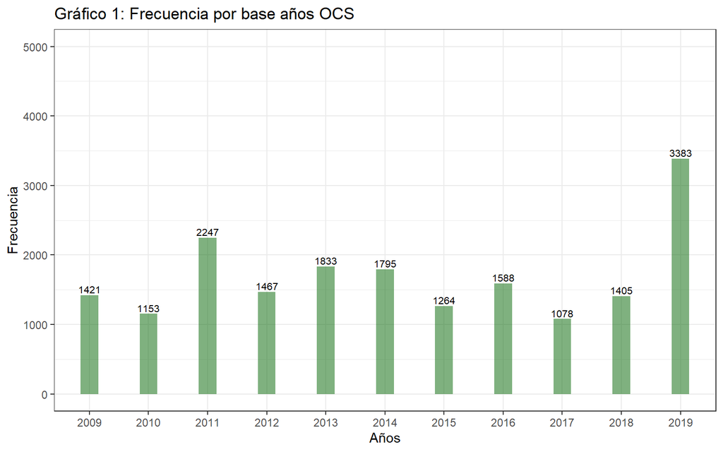

```r
# Frecuencias de la variable año
g1 <- df2 %>%
  group_by(ano) %>% # agrupamos por año
  summarise(freq = n()) # frecuencias de cada año

#Graficamos las frecuencias
ggplot(g1, aes(x = ano, y = freq)) +
  geom_col(fill="darkgreen", alpha=0.5,width = 0.3) + # Gráfico de barra
  geom_text(aes(label = freq ), vjust = -0.3, size= 2.75) + # leyendas de cada gráfíco
  theme_bw() +  # Fondo blanco
  labs(x="Años", # eje X
       y="Frecuencia", # eje Y
       title = "Gráfico 1: Frecuencia por base años OCS")+
  coord_cartesian(ylim=c(0,5000)) # Rango del eje
```

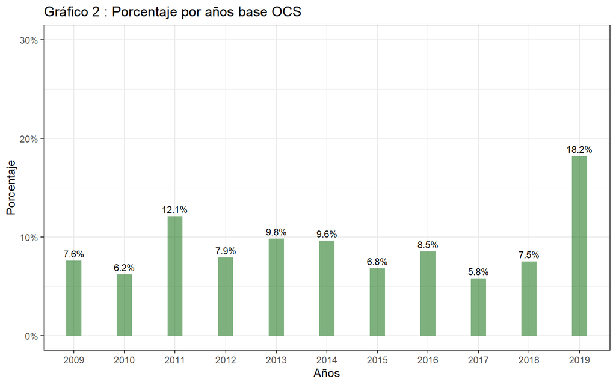

```r
# Porcentajes de la variable año
g2 <- g1 %>% arrange(desc(ano)) %>% # utilizamos los datos procesados en las frecuencias
  mutate(prop = round(freq/sum(freq),3)) # también puede ser mutate(prop = prop.table(prop))

#Gráficos los porcentajes
ggplot(g2, aes(x = ano, y = prop, label = scales::percent(prop, accuracy = .1))) +
    geom_col(fill="darkgreen", alpha=0.5,width = 0.3) +
    geom_text(position = position_dodge(width = .9),
              vjust = -0.5,
              size = 3) +
    scale_y_continuous(labels = scales::percent) +
  labs(x="Años",
       y="Porcentaje",
       title = "Gráfico 2 : Porcentaje por años base OCS") +
  theme_bw() +
  coord_cartesian(ylim=c(0,0.3))
```

```r
# Porcentajes de la variable region
g3 <- df2 %>% group_by(region) %>% # utilizando la misma fórmula de frecuencia y porcentaje a la vez
  summarise(freq = n()) %>%
  arrange(desc(region)) %>%
  mutate(prop = round(freq/sum(freq),3))
```

Un elemento útil a la hora de gráficar es el color. Para el caso de las regiones es necesario generar 16 colores que permitan distinguir cada una en un gráfico. Los colores en `ggplot2` son por defecto 11 en el caso de no colocarlos manualmente, por lo que generaremos una variable de color que usaremos constantemente para distinguir estas características en el caso de las regiones

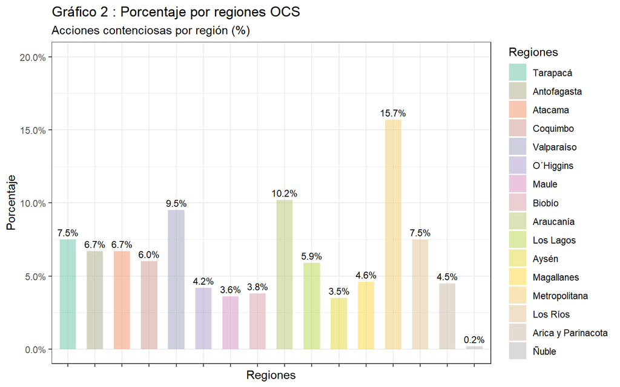

```r
#Gráficos los porcentajes

n.cols <- 16 # número de colores que necesitamos
#generamos los colores necesarios para cada región
colores <- colorRampPalette(brewer.pal(8, "Set2"))(n.cols) # librería RColorBrewer

ggplot(g3, aes(x = region, y = prop, fill=region, group=1, label = scales::percent(prop, accuracy = .1))) +
  geom_col(aes(fill=region),alpha=0.5,width = 0.6)+
  geom_text(position = position_dodge(width = .9),
              vjust = -0.5,
              size = 3) +
    scale_y_continuous(labels = scales::percent)  +
  scale_fill_manual(values = colores)+ #Utilizamos los colores generados
  labs(x="Regiones",
       y="Porcentaje",
       title = "Gráfico 2 : Porcentaje por regiones OCS",
       subtitle= "Acciones contenciosas por región (%)") +
  labs(fill = "Regiones") + # nombres y colores de regiones en la leyenda
  theme_bw()+
  theme(axis.text.x = element_blank()) + # evitamos superposición de nombres en el eje
   coord_cartesian(ylim=c(0,0.2))
```

## Bonus track - Estallido social

En el siguiente apartado realizamos un breve tratamiento de los eventos ocurridos durante el estallido social. Para realizar esto utilizamos las variables de fecha con las que cuenta la base y luego establecemos puntos de corte en el tiempo. Así mismo, y una vez establecido el corte temporal, generamos una variable que divida el tiempo en 2 semanas (aprox) entre el 18 de octubre y el 31 de diciembre del año 2019 con el fin de examinar la ocurrencia de eventos de protesta en distintos períodos.

```r
# Generar variable temporal
data$fecha<-as.Date(with(data,paste(ano,p5b,p5a,sep="-")),"%Y-%m-%d")

estallido<-data  %>%
  filter(fecha>= as.Date("2019-10-18") & fecha<=as.Date("2019-12-31")) # Subset de la base original


#Variable por semanas para el estallido
estallido<-estallido %>%  mutate(periodo =
         case_when(fecha >= ymd('2019-10-18') & fecha <= ymd('2019-10-31') ~ "1",
                   fecha >= ymd('2019-11-01') & fecha <= ymd('2019-11-15') ~ "2",
                   fecha >= ymd('2019-11-16') & fecha <= ymd('2019-11-30') ~ "3",
                   fecha >= ymd('2019-12-01') & fecha <= ymd('2019-12-15') ~ "4",
                   fecha >= ymd('2019-12-16') & fecha <= ymd('2019-12-31') ~ "5"))

#Etiquetamos los cortes de tiempo
estallido$periodo <- factor(estallido$periodo,labels = c('18oct-31oct', '1nov-15nov','16no-30nov','1dic-15dic','16dic-31dic'))
estallido$periodo <- set_label(estallido$periodo,label = "Período - estallido social")
```